# Limpet Egg Analysis

Pascal Bärtschi

2023-08-20

### Introduction

In this analysis, we’ll explore the relationships between limpet egg count and factors such as density and season. We’ll begin by loading the necessary libraries and importing the dataset. Let’s dive in!

```r
# Importing libraries
suppressPackageStartupMessages({
  # Importing libraries
  library("ggplot2")
  library("dplyr")
  library("ggfortify")
  library('tidyverse')
  library('GGally')
})


# Load data
# setwd("~/BSc_UZH/UZH_22FS/BIO144/datasets-master")
data <- read.csv('data/limpet.csv', stringsAsFactors = T)
```

### Data Exploration

We’ll start by getting a glimpse of the dataset to understand its structure and contents.

```r
glimpse(data)
```

```
## Rows: 24
## Columns: 3
## $ DENSITY <int> 8, 8, 8, 8, 8, 8, 15, 15, 15, 15, 15, 15, 30, 30, 30, 30, 30, ~
## $ SEASON  <fct> spring, spring, spring, summer, summer, summer, spring, spring~
## $ EGGS    <dbl> 2.875, 2.625, 1.750, 2.125, 1.500, 1.875, 2.600, 1.866, 2.066,~
```

Next, we’ll generate summary statistics to gain insights into the key features of the dataset.

```r
summary(data)
```

```
##     DENSITY         SEASON        EGGS
##  Min.   : 8.00   spring:12   Min.   :0.3560
##  1st Qu.:13.25   summer:12   1st Qu.:0.9165
##  Median :22.50               Median :1.4330
##  Mean   :24.50               Mean   :1.4717
##  3rd Qu.:33.75               3rd Qu.:1.9227
##  Max.   :45.00               Max.   :2.8750
```

### Visualizing Relations

Let’s visualize the relationship between egg count, density, and season using a scatter plot.

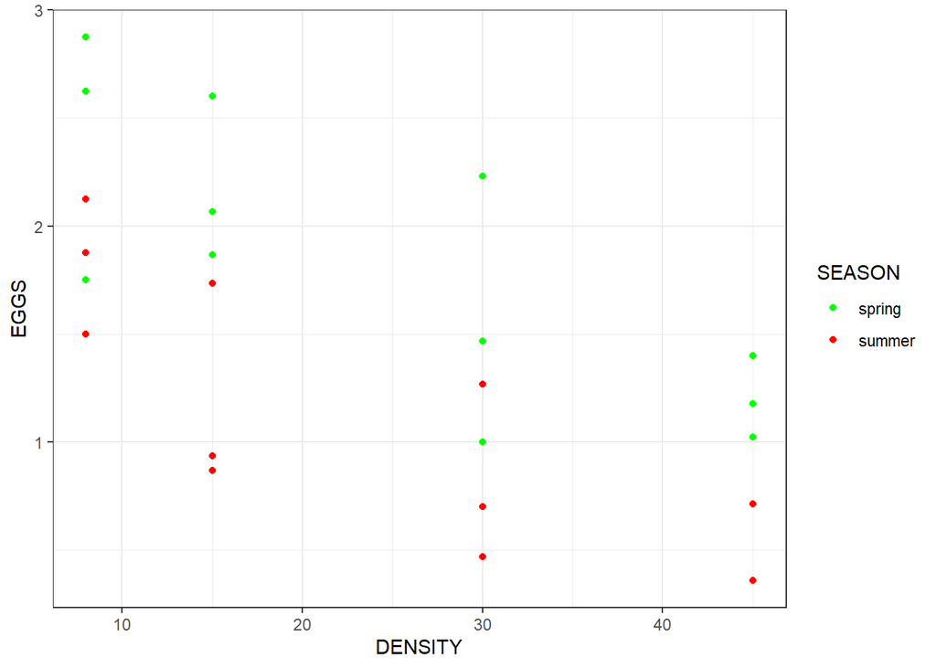

```r
ggplot(data, aes(x = DENSITY, y = EGGS, colour = SEASON)) +
  geom_point() +
  scale_color_manual(values = c(spring = "green", summer = "red")) +
  theme_bw()
```

### Model Construction

We’ll construct a linear regression model to understand how egg count is influenced by density and season.

```r
model_limp <- lm(EGGS ~ DENSITY * SEASON, data = data)
```

### Model Check and Interpretation

Let’s take a closer look at the model and its components.

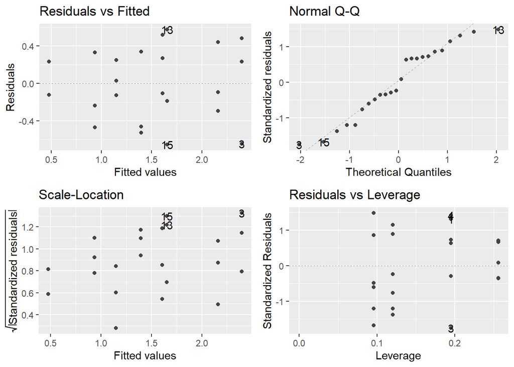

```r
autoplot(model_limp, smooth.colour = NA)
```

### ANOVA Table

An analysis of variance (ANOVA) will help us understand the significance of different factors in our model.

```r
anova(model_limp)
```

```
## Analysis of Variance Table
##
## Response: EGGS
##                Df Sum Sq Mean Sq F value    Pr(>F)
## DENSITY         1 5.0241  5.0241 30.1971 2.226e-05 ***
## SEASON          1 3.2502  3.2502 19.5350 0.0002637 ***
## DENSITY:SEASON  1 0.0118  0.0118  0.0711 0.7925333
## Residuals      20 3.3275  0.1664
## ---
## Signif. codes:  0 '***' 0.001 '**' 0.01 '*' 0.05 '.' 0.1 ' ' 1
```

### Model Summary

The summary of the linear regression model provides important insights into the relationships we’re exploring.

```r
summary(model_limp)
```

```
##
## Call:
## lm(formula = EGGS ~ DENSITY * SEASON, data = data)
##
## Residuals:
##      Min       1Q   Median       3Q      Max
## -0.65468 -0.25021 -0.03318  0.28335  0.57532
##
## Coefficients:
##                       Estimate Std. Error t value Pr(>|t|)
## (Intercept)           2.664166   0.234118  11.380 3.45e-10 ***
## DENSITY              -0.033650   0.008259  -4.074 0.000591 ***
## SEASONsummer         -0.812282   0.331092  -2.453 0.023450 *
## DENSITY:SEASONsummer  0.003114   0.011680   0.267 0.792533
## ---
## Signif. codes:  0 '***' 0.001 '**' 0.01 '*' 0.05 '.' 0.1 ' ' 1
##
## Residual standard error: 0.4079 on 20 degrees of freedom
## Multiple R-squared:  0.7135, Adjusted R-squared:  0.6705
## F-statistic:  16.6 on 3 and 20 DF,  p-value: 1.186e-05
```

### Coefficient Table

The coefficients of the model reveal specific impact levels of the factors on egg count.

```r
coef(model_limp)
```

```
##          (Intercept)              DENSITY         SEASONsummer
##          2.664166462         -0.033649651         -0.812282493
## DENSITY:SEASONsummer
##          0.003113571
```

### Predictions and Visualization

We’ll use the model to make predictions and visualize the results.

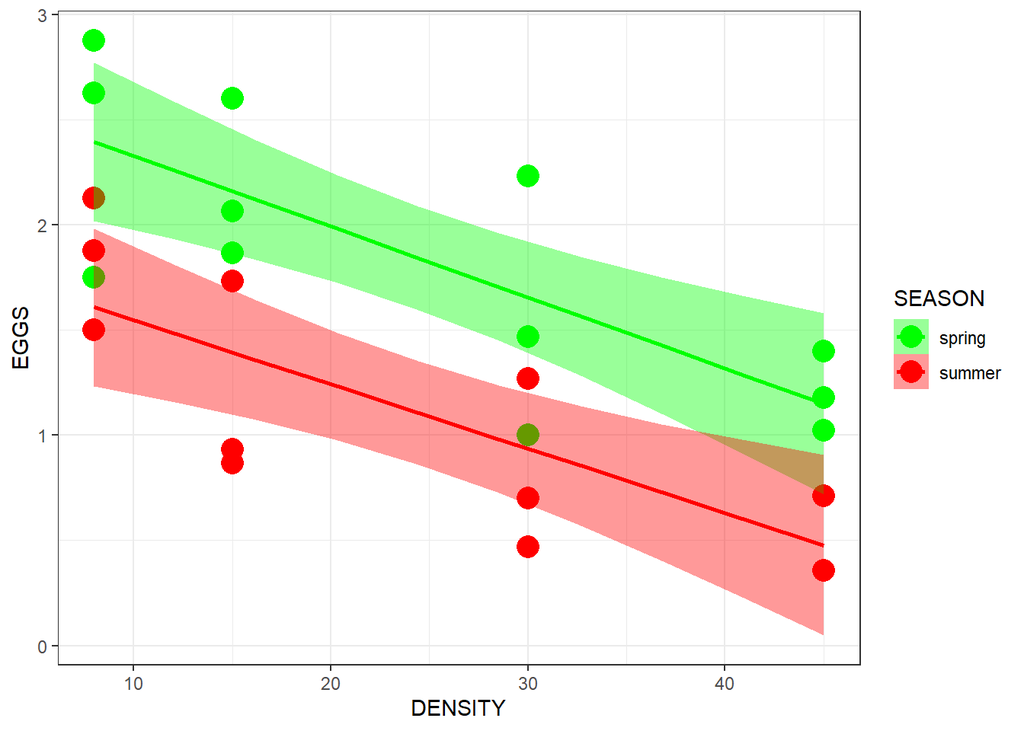

```r
new_x <- expand.grid(DENSITY = seq(from = 8, to = 45, length.out = 10),
                     SEASON = levels(data$SEASON))

predEGG <- predict(model_limp, newdata = new_x, interval = 'confidence')

addThese <- data.frame(new_x, predEGG)
addThese <- rename(addThese, EGGS = fit)

EGGatMeanDens <- data.frame(new_x, predEGG)
EGGatMeanDens <- rename(EGGatMeanDens, EGGS = fit)

ggplot(data, aes(x= DENSITY, y = EGGS, colour = SEASON)) +
  geom_point(size = 5) +
  geom_smooth(data = addThese,
              aes(ymin = lwr, ymax = upr, fill = SEASON), stat = 'identity') +
  scale_color_manual(values = c(spring = 'green', summer = 'red')) +
  scale_fill_manual(values = c(spring = 'green', summer = 'red')) +
  theme_bw()
```

### Conclusion and Interpretation

In conclusion, our analysis provides insights into the relationships between egg count, density, and season in limpets. The visualizations and statistical analysis allow us to better understand these dynamics.